# Ramp Lab picks — in practice

The six winning ramps from the 2026-07-18 review, applied to dummy housing data

Published

July 18, 2026

Companion to REVIEW.md. Each ramp below is built with the exact `colorspace` call from its dashboard “Copy R snippet” (verified against real colorspace output during the review) and applied to simple dummy housing data. Charts use `theme_minimal()` on purpose — the point is to judge the **color ramps** in realistic chart shapes, before the branded hdatools themes enter the picture.

**Setup: ramp constructors (the verified snippets) + dummy data**

```r
library(ggplot2)
library(colorspace)

# Sequential picks: one sequential_hcl() call each.
seq_ramp <- function(n, h1, c1, l1, power) {
  sequential_hcl(n, h = c(h1, 80), c = c(c1, 10), l = c(l1, 95), power = power)
}

# Diverging picks: two sequential_hcl() arms stitched (diverging_hcl() can't
# express the shared cream center) — same construction as generate_candidates.R.
div_ramp <- function(n, h1, h2, c1, l1, power) {
  n2 <- ceiling(n / 2)
  arm <- function(h) sequential_hcl(n2, h = c(h, 80), c = c(c1, 10), l = c(l1, 95), power = power)
  out <- c(arm(h1), rev(arm(h2)))
  if (floor(n / 2) < n2) out <- out[-n2]
  out
}

pal <- list(
  hda_seq = function(n) seq_ramp(n, h1 = 259.2, c1 = 64, l1 = 26, power = 0.85),
  hda_div = function(n) div_ramp(n, h1 = 259.2, h2 = 20.4, c1 = 76, l1 = 26, power = 0.90),
  hfv_seq = function(n) seq_ramp(n, h1 = 118.5, c1 = 65, l1 = 28, power = 1.00),
  hfv_div = function(n) div_ramp(n, h1 = 118.5, h2 = 344.0, c1 = 68, l1 = 26, power = 0.95),
  pha_seq = function(n) seq_ramp(n, h1 = 19.7, c1 = 84, l1 = 28, power = 0.95),
  pha_div = function(n) div_ramp(n, h1 = 243.4, h2 = 19.7, c1 = 72, l1 = 26, power = 0.90)
)

# ---- Dummy data (seeded, shared by all brands so only the palette varies) ----
set.seed(20260718)

# Fake tract grid with a smooth-ish spatial field: share of cost-burdened renters.
tracts <- expand.grid(col = 1:12, row = 1:8)
tracts$burden <- with(tracts, plogis(
  0.35 * sin(col / 2.2) + 0.45 * cos(row / 1.8) + 0.12 * col / 6 + rnorm(nrow(tracts), 0, 0.35)
))
# Rescale to span all 7 classes so every legend key is populated.
tracts$burden <- with(tracts, (burden - min(burden)) / diff(range(burden)) * 0.96 + 0.02)

# Households by income band (ordinal -> legitimate one-hue ramp use).
bands <- data.frame(
  band  = factor(c("<15k", "15-30k", "30-50k", "50-75k", "75-100k", "100-150k", "150k+"),
                 levels = c("<15k", "15-30k", "30-50k", "50-75k", "75-100k", "100-150k", "150k+")),
  share = c(0.08, 0.12, 0.17, 0.20, 0.16, 0.15, 0.12)
)

# Homeownership rate by age cohort over time (lines use the ramp's darker half).
years   <- 2015:2025
cohorts <- c("Under 35", "35-54", "55-74", "75+")
own <- expand.grid(year = years, cohort = factor(cohorts, levels = cohorts))
own$rate <- with(own, c(0.36, 0.62, 0.75, 0.79)[as.integer(cohort)] +
                   0.004 * (year - 2015) * c(-1, 0.4, 0.6, 0.2)[as.integer(cohort)] +
                   rnorm(nrow(own), 0, 0.006))

# Change in median rent, 2020 -> 2025, by locality (diverging).
localities <- paste0("Locality ", LETTERS[1:12])
rent_chg <- data.frame(
  locality = localities,
  change   = round(sort(runif(12, -0.18, 0.24)), 3)
)

# The same tract grid re-expressed as change vs regional baseline (diverging map).
tracts$rent_change <- (tracts$burden - mean(tracts$burden)) * 0.55 +
  rnorm(nrow(tracts), 0, 0.02)

# ---- Small plotting helpers reused for every brand ----
theme_demo <- theme_minimal(base_size = 12) +
  theme(panel.grid.minor = element_blank(), plot.title.position = "plot")

swatch_plot <- function(hex, title) {
  d <- data.frame(x = seq_along(hex), hex = hex)
  ggplot(d, aes(x, 1, fill = hex)) +
    geom_tile(color = "white", linewidth = 1) +
    geom_text(aes(label = hex), y = 0.35, size = 3, family = "mono") +
    scale_fill_identity() +
    coord_cartesian(ylim = c(0.2, 1.6), expand = FALSE) +
    labs(title = title) +
    theme_void(base_size = 12) + theme(plot.title = element_text(size = 11))
}

map_seq <- function(hex7) {
  # sequential_hcl() returns dark -> light; on a value-labeled map, HIGH
  # values wear the DARK end, so the fill scale takes the reversed ramp.
  brks <- seq(0, 1, length.out = 8)
  labs7 <- paste0(head(round(brks * 100), 7), "-", round(brks[-1] * 100), "%")
  d <- tracts
  d$class <- cut(d$burden, brks, labels = labs7, include.lowest = TRUE)
  ggplot(d, aes(col, row, fill = class)) +
    geom_tile(color = "white", linewidth = 0.8) +
    scale_fill_manual(values = rev(hex7), name = "Cost-burdened\nrenters", drop = FALSE) +
    coord_equal() +
    labs(title = "Choropleth-style: share of renters cost-burdened, by tract") +
    theme_void(base_size = 11) + theme(plot.title = element_text(size = 11))
}

bars_seq <- function(hex7) {
  ggplot(bands, aes(band, share, fill = band)) +
    geom_col(width = 0.75) +
    scale_fill_manual(values = rev(hex7), guide = "none") +
    scale_y_continuous(labels = scales::percent) +
    labs(title = "Ordinal bars: households by income band",
         x = NULL, y = NULL) +
    theme_demo
}

lines_seq <- function(hex7) {
  # Lines take the ramp's darker half - the two palest classes are for fills,
  # not strokes (they'd vanish against white).
  cols <- hex7[c(1, 2, 3, 4)]
  ggplot(own, aes(year, rate, color = cohort)) +
    geom_line(linewidth = 1) +
    scale_color_manual(values = cols, name = NULL) +
    scale_y_continuous(labels = scales::percent) +
    scale_x_continuous(breaks = seq(2015, 2025, 2)) +
    labs(title = "Lines: homeownership rate by age cohort (darker half of ramp)",
         x = NULL, y = NULL) +
    theme_demo
}

divbars <- function(hex7) {
  d <- rent_chg
  brks <- seq(-0.25, 0.25, length.out = 8)
  d$class <- cut(d$change, brks, include.lowest = TRUE)
  ggplot(d, aes(reorder(locality, change), change, fill = class)) +
    geom_col(width = 0.75) +
    geom_hline(yintercept = 0, color = "grey40") +
    scale_fill_manual(values = hex7, guide = "none", drop = FALSE) +
    scale_y_continuous(labels = scales::percent) +
    coord_flip() +
    labs(title = "Diverging bars: change in median rent, 2020-2025",
         x = NULL, y = NULL) +
    theme_demo
}

map_div <- function(hex7) {
  brks <- seq(-0.15, 0.15, length.out = 8)
  labs7 <- paste0(head(round(brks * 100), 7), " to ", round(brks[-1] * 100), "%")
  d <- tracts
  d$class <- cut(pmin(pmax(d$rent_change, -0.149), 0.149), brks, labels = labs7)
  ggplot(d, aes(col, row, fill = class)) +
    geom_tile(color = "white", linewidth = 0.8) +
    scale_fill_manual(values = hex7, name = "Rent change\nvs region", drop = FALSE) +
    coord_equal() +
    labs(title = "Choropleth-style: rent change vs regional baseline, by tract") +
    theme_void(base_size = 11) + theme(plot.title = element_text(size = 11))
}
```

# HDA

## Sequential — Blue → cream (tuned: chroma 64, power 0.85)

Navy → teal → sage → cream. The power-0.85 tune moves class boundaries darker, so midtones keep conviction and the pale classes stay legible against white instead of going chalky. Mid-ramp deliberately reads teal — that hue passage is the shared-cream system’s signature across all three brands.

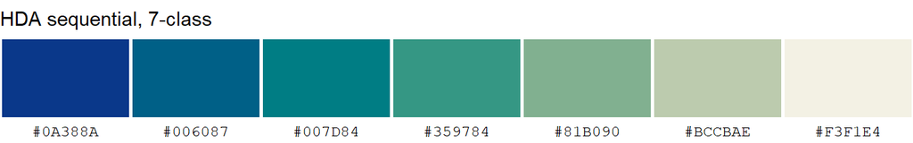

Figure 1

```r
swatch_plot(pal$hda_seq(7), "HDA sequential, 7-class")
```

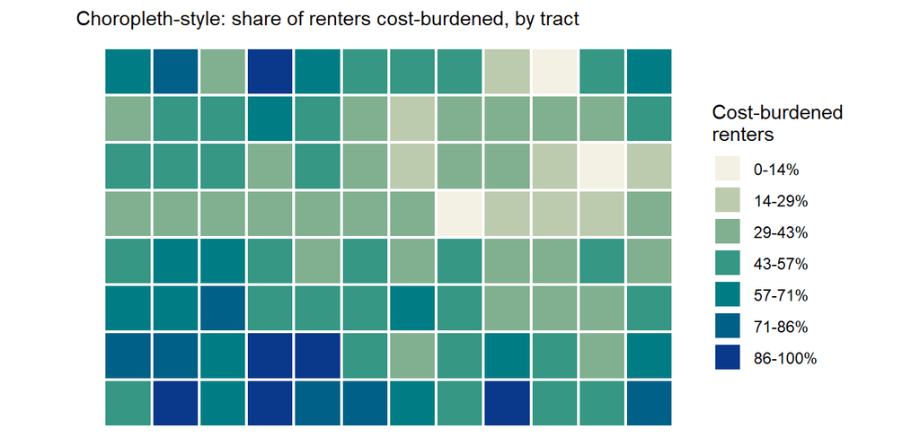

Figure 2

```r
map_seq(pal$hda_seq(7))
```

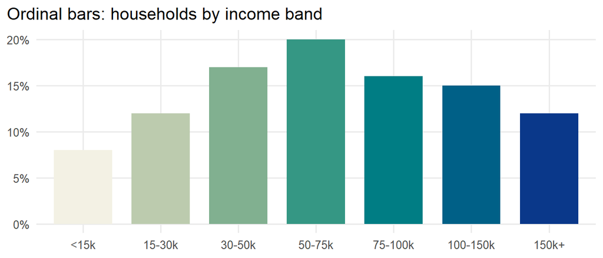

Figure 3

```r
bars_seq(pal$hda_seq(7))
```

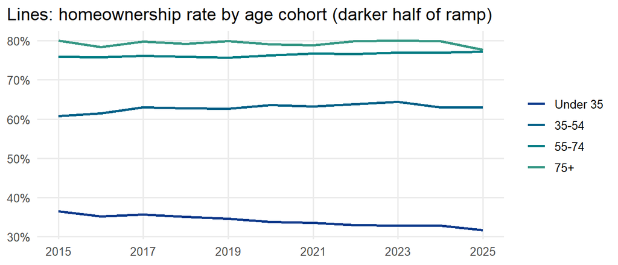

Figure 4

```r
lines_seq(pal$hda_seq(7))
```

## Diverging — Blue vs Coral (tuned: chroma 76, lum 26, power 0.9)

The flagship brand pairing: navy/teal against sienna/brick over the shared cream center. Deeper tips and richer inner classes than the generated default. Usage note from the review: on 7-class diverging *maps*, keep a legend — the innermost pale pair loses sign distinction under protanopia.

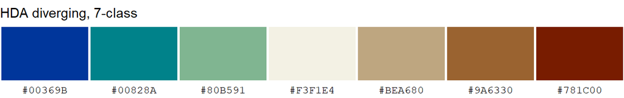

Figure 5

```r
swatch_plot(pal$hda_div(7), "HDA diverging, 7-class")
```

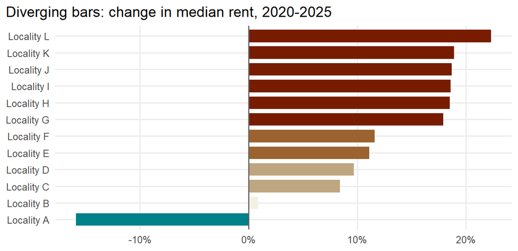

Figure 6

```r
divbars(pal$hda_div(7))
```

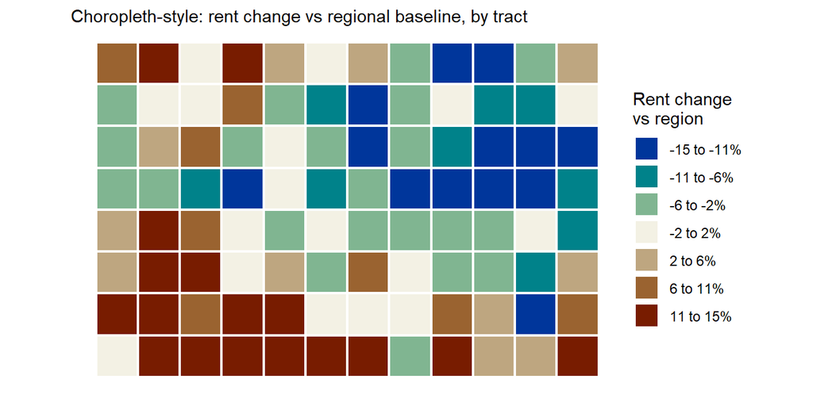

Figure 7

```r
map_div(pal$hda_div(7))
```

# HFV

## Sequential — Leaf → cream (generated defaults, kept deliberately)

A true green ramp built on the experimental Leaf secondary — it gives HFV its own identity next to HDA’s navy-teal. Twelve slider variants were tested during the review; every one traded away a color-vision-deficiency floor (dark greens are gamut-limited), so the generated parameters stand.

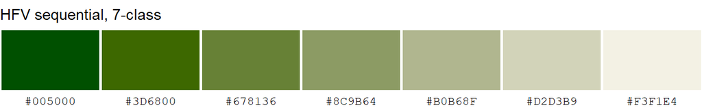

Figure 8

```r
swatch_plot(pal$hfv_seq(7), "HFV sequential, 7-class")
```

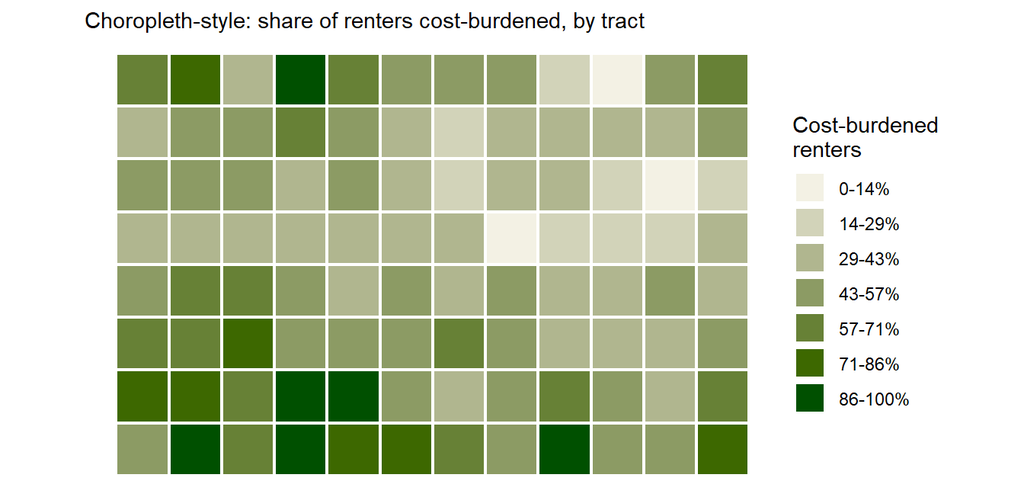

Figure 9

```r
map_seq(pal$hfv_seq(7))
```

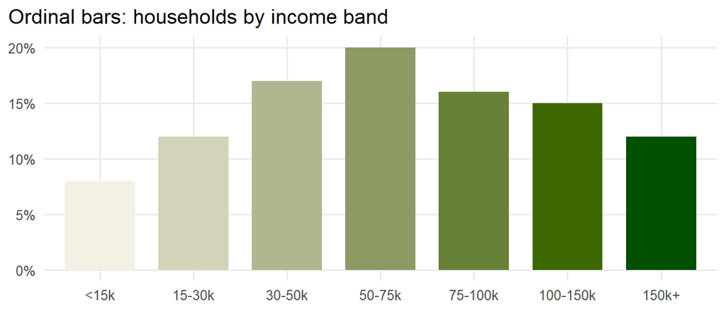

Figure 10

```r
bars_seq(pal$hfv_seq(7))
```

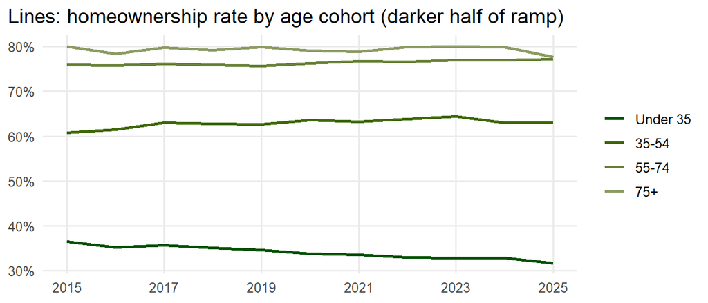

Figure 11

```r
lines_seq(pal$hfv_seq(7))
```

## Diverging — Leaf vs Berry (tuned: chroma 68, lum 26, power 0.95)

Green vs berry-wine, PiYG-family — HFV’s own diverging axis rather than a second navy-vs-tan. It was the most CVD-robust diverging candidate in its slot by a wide margin (worst cross-arm ΔE anywhere ≈ 16 after tuning; the Desert pairings collapse to 2–4 on the protan inner pair). The berry arm passes through periwinkle/seafoam near center — luminance order and the legend carry that, same as ColorBrewer’s PiYG.

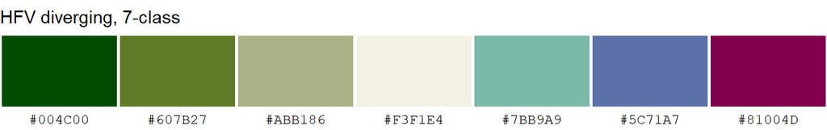

Figure 12

```r
swatch_plot(pal$hfv_div(7), "HFV diverging, 7-class")
```

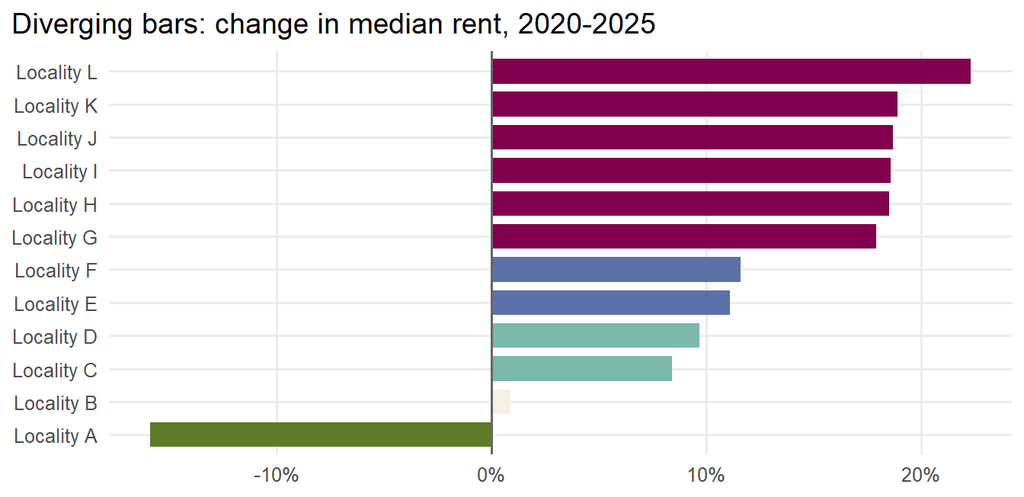

Figure 13

```r
divbars(pal$hfv_div(7))
```

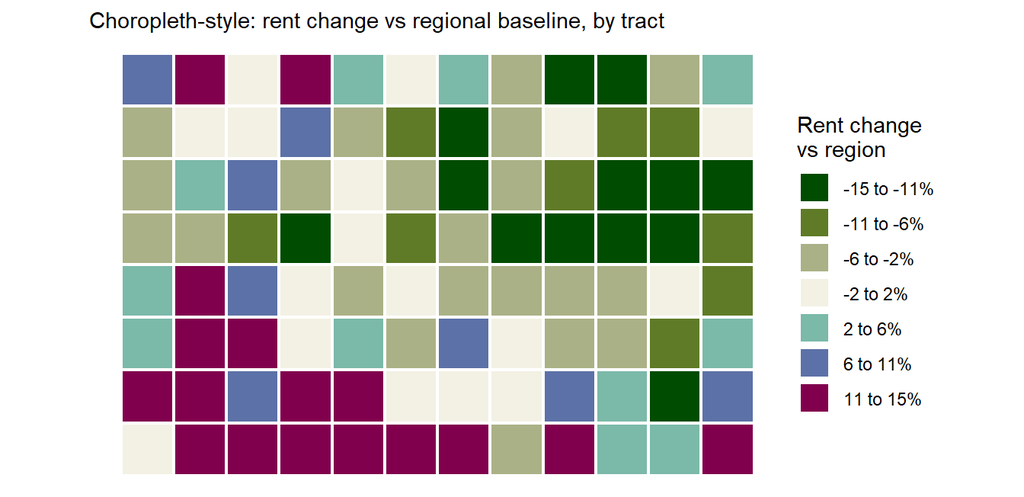

Figure 14

```r
map_div(pal$hfv_div(7))
```

# PHA

## Sequential — Red → cream (tuned: chroma 84, power 0.95)

Oxide-red / terracotta, completing a blue–green–red system across the three brands. The tune (chroma 90 → 84, power 0.95) was the rare move that improved every color-vision floor at once — less dark-end saturation gives deuteranopia more luminance to work with, and the eased curve feeds the light classes.

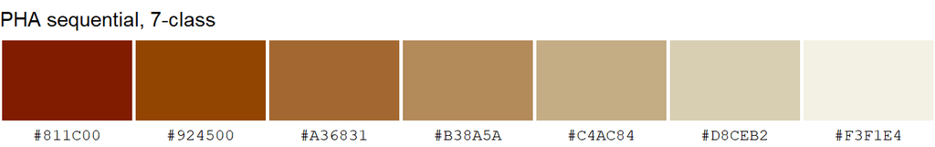

Figure 15

```r
swatch_plot(pal$pha_seq(7), "PHA sequential, 7-class")
```

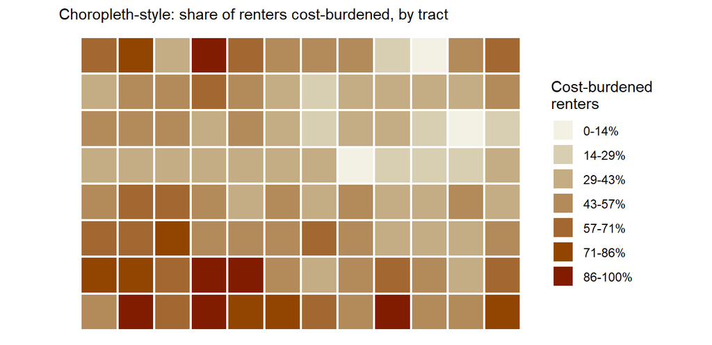

Figure 16

```r
map_seq(pal$pha_seq(7))
```

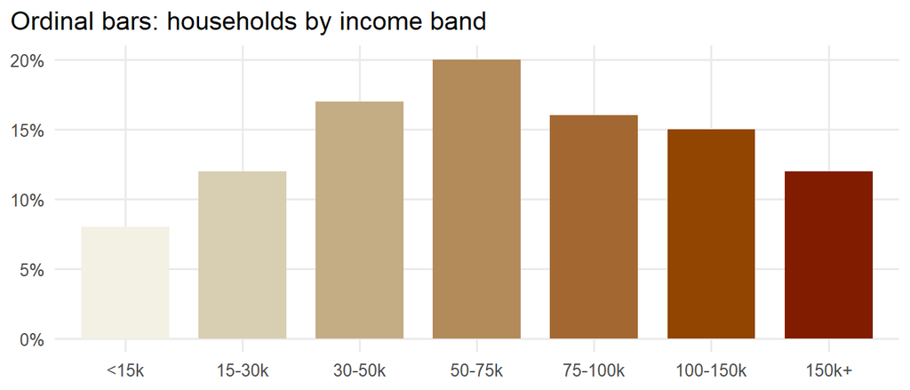

Figure 17

```r
bars_seq(pal$pha_seq(7))
```

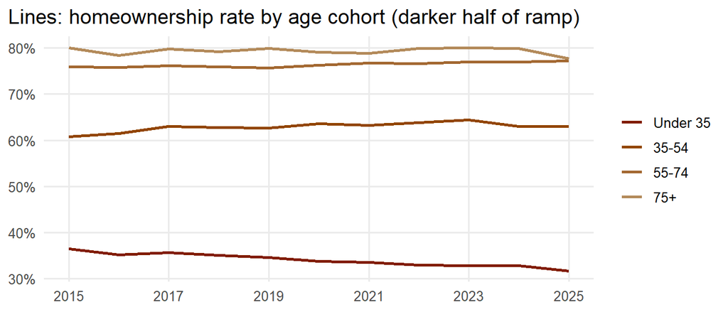

Figure 18

```r
lines_seq(pal$pha_seq(7))
```

## Diverging — Dark Blue vs Red (tuned: chroma 72, lum 26, power 0.9)

PHA’s two flagship civic colors, tuned with the same treatment as HDA’s diverging so the two cool-warm divergings stay system-coherent. Same usage note as HDA: legend/labels on 7-class diverging maps (protan inner pair).

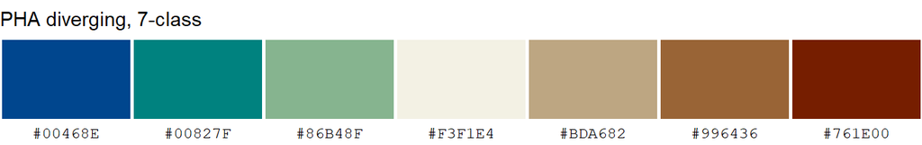

Figure 19

```r
swatch_plot(pal$pha_div(7), "PHA diverging, 7-class")
```

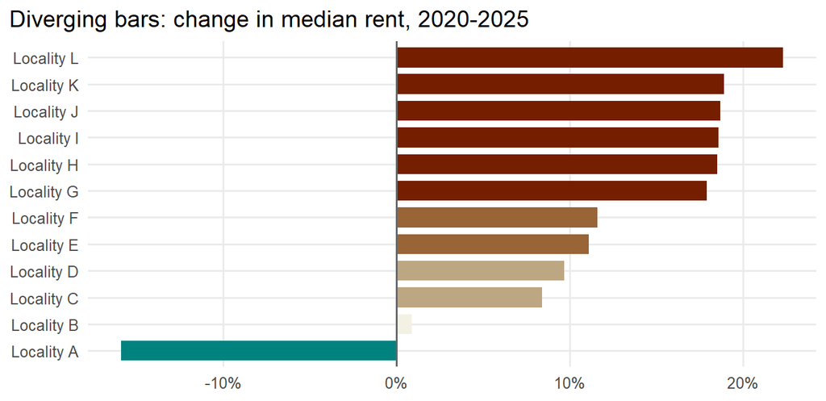

Figure 20

```r
divbars(pal$pha_div(7))
```

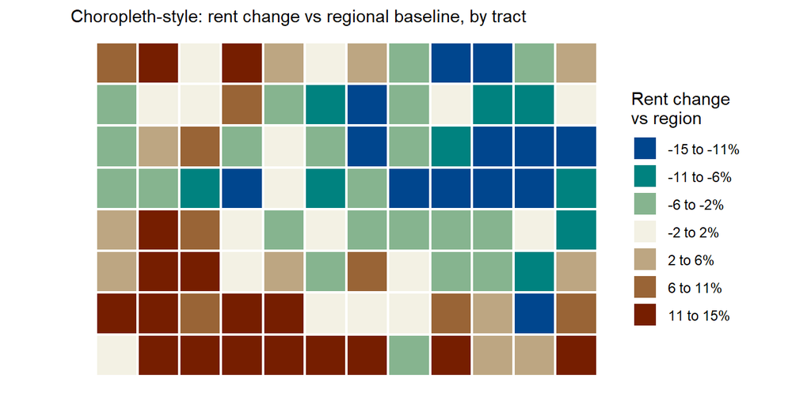

Figure 21

```r
map_div(pal$pha_div(7))
```

# The family together

All six picks share the same cream light-end/center (H≈80, C≈10, L≈95), the same class rhythm, and similar dark-end weight — one design system, three distinct brand identities. The two cool-warm divergings (HDA, PHA) are deliberate siblings; see REVIEW.md for the cross-brand discussion.

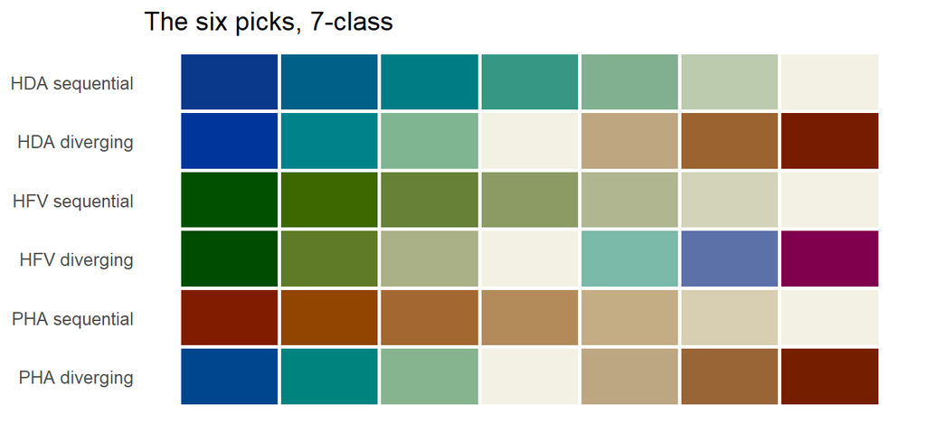

Figure 22

```r
fam <- do.call(rbind, lapply(names(pal), function(nm) {
  data.frame(ramp = nm, x = 1:7, hex = pal[[nm]](7))
}))
fam$ramp <- factor(fam$ramp, levels = rev(c("hda_seq", "hda_div", "hfv_seq",
                                            "hfv_div", "pha_seq", "pha_div")),
                   labels = rev(c("HDA sequential", "HDA diverging", "HFV sequential",
                                  "HFV diverging", "PHA sequential", "PHA diverging")))
ggplot(fam, aes(x, ramp, fill = hex)) +
  geom_tile(color = "white", linewidth = 1) +
  scale_fill_identity() +
  labs(title = "The six picks, 7-class", x = NULL, y = NULL) +
  theme_minimal(base_size = 12) +
  theme(panel.grid = element_blank(), axis.text.x = element_blank())
```

**NoteWhat happens next**

Nothing here touches `R/` yet. Adoption into hdatools (scale functions, n-class defaults, documentation) is a separate step once these picks are signed off. The exact construction calls live in REVIEW.md and in the `setup` chunk above.